# Modeling and prediction for movies

## Setup

### Load packages

```r
library(ggplot2)
library(dplyr)
library(statsr)
```

### Load data

Make sure your data and R Markdown files are in the same directory. When loaded your data file will be called `movies`. Delete this note when before you submit your work.

```r
load("movies.Rdata")
```

## Part 1: Data

The data is collected from the fact related to the movie. All the data was recoreded from the votes of audience. Thus, we only can answer the question about generalizability but not about the cauality. We can confirm that the ramdom sampling was used becuase we can recognize that the movie is not from specific categories. Otherwise, each observation is independent.

## Part 2: Research question

How do the critics score, audience score, best-actor-winning and best-actress-winning correlate with imdb rating?

Knowing the relationship between imdb rating and other varaibles, marketer can predict the imdb rating and create a more comprehensive marketing strategy to promote the movies online.

## Part 3: Exploratory data analysis

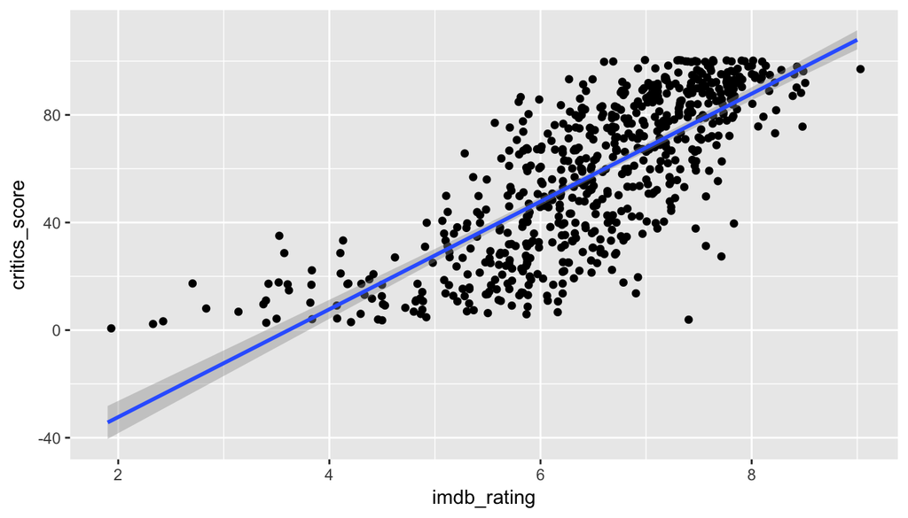

```r
ggplot(data = movies, aes(x = imdb_rating, y = critics_score)) +
    geom_jitter() +
  geom_smooth(method = "lm")
```

The graphic above shows the distribution of the critics score when the x is imdb rating. We can see that there is a potential linear relationship between these two variables. So, we should explore the two variables.

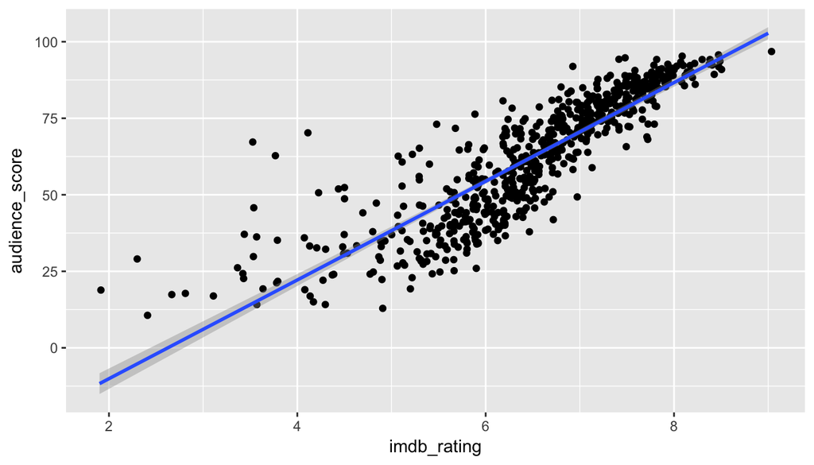

```r
ggplot(data = movies, aes(x = imdb_rating, y = audience_score)) +
    geom_jitter() +
  geom_smooth(method = "lm")
```

The graphic above shows the distribution of the audience score when the x is imdb rating. We can see that there is a potential linear relationship between these two variables. So, we should explore the two variables.

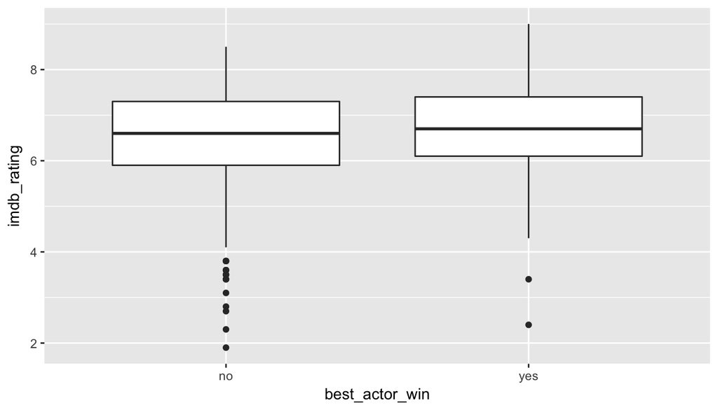

```r
ggplot(data = movies, aes(x=best_actor_win, y=imdb_rating))+geom_boxplot()
```

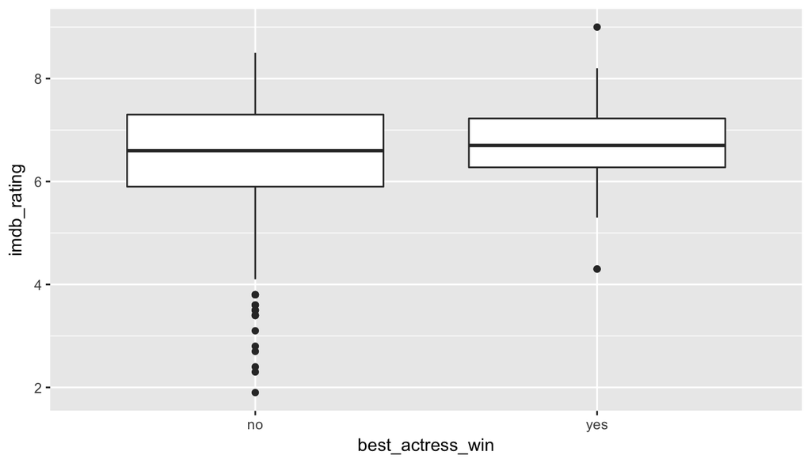

```r
ggplot(data=movies, aes(x=best_actress_win, y=imdb_rating))+geom_boxplot()
```

## Part 4: Modeling

I firstly chose the critics score, audience score, best picture winning status, best actor winning status and best actress winning status for building the model.

Then, I used p-value backward elimination to elimate the predictor that is not significant to the model. So, I final model contains the critic score, audience score and best actor winning status.

We can see that all the variables have a p-value lower than 0.05. The r squared in the summary result also shows that the model could explain 79% of the data.

```r
Movietest= lm(imdb_rating~critics_score+ audience_score+ best_pic_win+best_actor_win+best_actress_win, data = movies)
summary(Movietest)
```

```
##
## Call:
## lm(formula = imdb_rating ~ critics_score + audience_score + best_pic_win +
##     best_actor_win + best_actress_win, data = movies)
##
## Residuals:
##      Min       1Q   Median       3Q      Max
## -2.50431 -0.21653  0.03308  0.30743  1.25057
##
## Coefficients:
##                      Estimate Std. Error t value Pr(>|t|)
## (Intercept)         3.6295434  0.0629955  57.616   <2e-16 ***
## critics_score       0.0115834  0.0009534  12.150   <2e-16 ***
## audience_score      0.0347527  0.0013358  26.016   <2e-16 ***
## best_pic_winyes     0.1823164  0.1892431   0.963   0.3357
## best_actor_winyes   0.1063849  0.0552553   1.925   0.0546 .
## best_actress_winyes 0.0985219  0.0623465   1.580   0.1145
## ---
## Signif. codes:  0 '***' 0.001 '**' 0.01 '*' 0.05 '.' 0.1 ' ' 1
##
## Residual standard error: 0.4882 on 645 degrees of freedom
## Multiple R-squared:  0.799,  Adjusted R-squared:  0.7974
## F-statistic: 512.7 on 5 and 645 DF,  p-value: < 2.2e-16
```

```r
Movie1= lm(imdb_rating~critics_score+ audience_score+best_actor_win+best_actress_win, data = movies)
summary(Movie1)
```

```
##
## Call:
## lm(formula = imdb_rating ~ critics_score + audience_score + best_actor_win +
##     best_actress_win, data = movies)
##
## Residuals:
##      Min       1Q   Median       3Q      Max
## -2.50293 -0.21540  0.03017  0.30940  1.25149
##
## Coefficients:
##                      Estimate Std. Error t value Pr(>|t|)
## (Intercept)         3.6241371  0.0627416  57.763   <2e-16 ***
## critics_score       0.0116300  0.0009521  12.215   <2e-16 ***
## audience_score      0.0348100  0.0013344  26.087   <2e-16 ***
## best_actor_winyes   0.1073813  0.0552426   1.944   0.0524 .
## best_actress_winyes 0.1072006  0.0616888   1.738   0.0827 .
## ---
## Signif. codes:  0 '***' 0.001 '**' 0.01 '*' 0.05 '.' 0.1 ' ' 1
##
## Residual standard error: 0.4882 on 646 degrees of freedom
## Multiple R-squared:  0.7987, Adjusted R-squared:  0.7974
## F-statistic: 640.7 on 4 and 646 DF,  p-value: < 2.2e-16
```

```r
Movie2= lm(imdb_rating~critics_score+ audience_score+best_actor_win, data = movies)
summary(Movie2)
```

```
##
## Call:
## lm(formula = imdb_rating ~ critics_score + audience_score + best_actor_win,
##     data = movies)
##
## Residuals:
##      Min       1Q   Median       3Q      Max
## -2.50796 -0.20653  0.02712  0.30476  1.24275
##
## Coefficients:
##                    Estimate Std. Error t value Pr(>|t|)
## (Intercept)       3.6320337  0.0626744  57.951   <2e-16 ***
## critics_score     0.0117189  0.0009522  12.307   <2e-16 ***
## audience_score    0.0347620  0.0013362  26.016   <2e-16 ***
## best_actor_winyes 0.1201652  0.0548359   2.191   0.0288 *
## ---
## Signif. codes:  0 '***' 0.001 '**' 0.01 '*' 0.05 '.' 0.1 ' ' 1
##
## Residual standard error: 0.489 on 647 degrees of freedom
## Multiple R-squared:  0.7977, Adjusted R-squared:  0.7968
## F-statistic: 850.6 on 3 and 647 DF,  p-value: < 2.2e-16
```

```r
Movie_final= lm(imdb_rating~critics_score+ audience_score+best_actor_win, data = movies)
summary(Movie_final)
```

```
##
## Call:
## lm(formula = imdb_rating ~ critics_score + audience_score + best_actor_win,
##     data = movies)
##
## Residuals:
##      Min       1Q   Median       3Q      Max
## -2.50796 -0.20653  0.02712  0.30476  1.24275
##
## Coefficients:
##                    Estimate Std. Error t value Pr(>|t|)
## (Intercept)       3.6320337  0.0626744  57.951   <2e-16 ***
## critics_score     0.0117189  0.0009522  12.307   <2e-16 ***
## audience_score    0.0347620  0.0013362  26.016   <2e-16 ***
## best_actor_winyes 0.1201652  0.0548359   2.191   0.0288 *
## ---
## Signif. codes:  0 '***' 0.001 '**' 0.01 '*' 0.05 '.' 0.1 ' ' 1
##
## Residual standard error: 0.489 on 647 degrees of freedom
## Multiple R-squared:  0.7977, Adjusted R-squared:  0.7968
## F-statistic: 850.6 on 3 and 647 DF,  p-value: < 2.2e-16
```

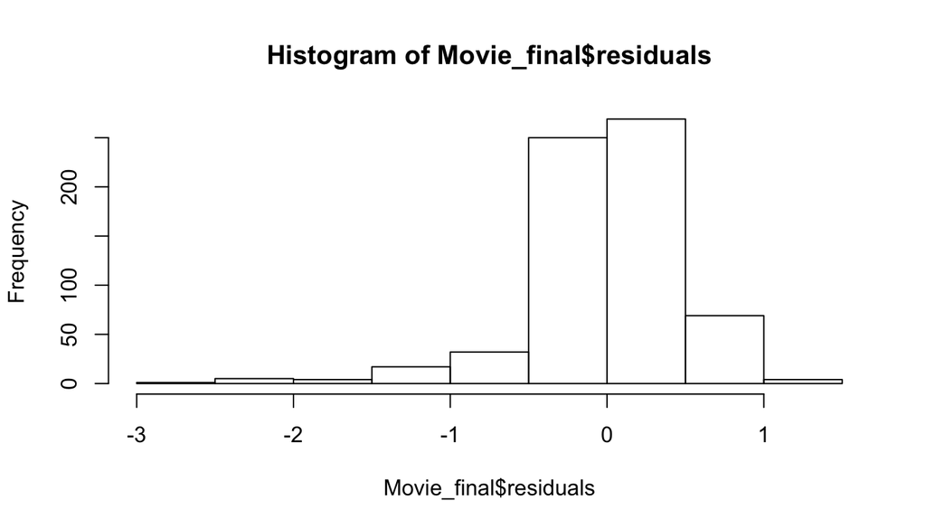

```r
hist(Movie_final$residuals)
```

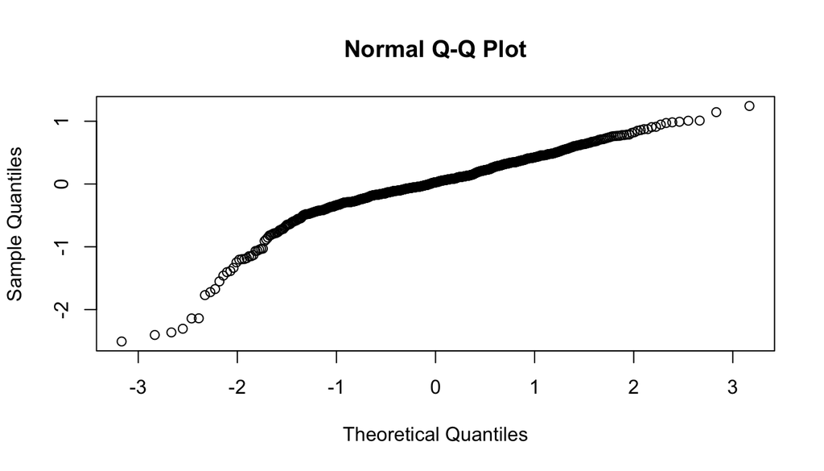

```r
qqnorm(Movie_final$residuals)
```

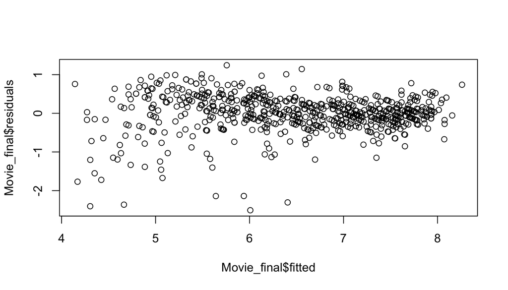

```r
plot(Movie_final$residuals~ Movie_final$fitted)
```

## Part 5: Prediction

I pick the movie “Moonlight” to test my model. The critics score, audience score and actor-winning information is from Rottentomatoes.com.

```r
newdata1= data.frame(critics_score=98, audience_score=79, best_actor_win="no")
predict(Movie_final, newdata1, interval = "confidence")
```

```
##        fit      lwr      upr
## 1 7.526684 7.458229 7.595139
```

After applying the scores to the model, we can see the fit is approximately 7.53 and the lower and upper result is around 7.46 and 7.6.

Because we use the defult 95% as the confidnece interval, we can said that we are 95% confident that,the model predicts that a movie that receive 98 for critics score, 79 for audience score and did not win the best actor may receive a imdb rating between 7.46 and 7.6

## Part 6: Conclusion

In conclusion, the award winning status has smaller impact on imdb rating prediction than other critical scores because the other socres are more correlated with the imdb rating.

The final model gives the viewer a way to predict the imdb rating. If the marketers can predict the rating with this model, they can suggest the movie publishing company to pormote the movie with a great rating and to attract more customers to buy the DVD or the digital movie.

The shortcoming of my study would be that I did not considered all the variables while building the model. This shortcoming may cause the problem that my model cannot be widely used in prediciton becuase the model did not contain other variables.